# project_1

Sijian Xuan sx2195

September 15, 2017

# Step 0: check and install needed packages. Load the libraries and functions.

```r
packages.used=c("qdap", "tm","topicmodels", "wordcloud", "RColorBrewer", "dplyr", "tidytext")

# check packages that need to be installed.
packages.needed=setdiff(packages.used,
                        intersect(installed.packages()[,1],
                                  packages.used))
# install additional packages
if(length(packages.needed)>0){
  install.packages(packages.needed, dependencies = TRUE)
}

# load packages
library("qdap")
library("dplyr")
library("tm")
library("topicmodels")
library("wordcloud")
library("RColorBrewer")
library("tidytext")
```

This notebook was prepared with the following environmental settings.

```r
print(R.version)
```

```
##                _
## platform       x86_64-apple-darwin13.4.0
## arch           x86_64
## os             darwin13.4.0
## system         x86_64, darwin13.4.0
## status
## major          3
## minor          3.1
## year           2016
## month          06
## day            21
## svn rev        70800
## language       R
## version.string R version 3.3.1 (2016-06-21)
## nickname       Bug in Your Hair
```

# Step 1 - Read in the speeches and make the sentence list

```r
folder.path="/Users/xuansijian/Documents/GitHub/fall2017-project1-sxuan2/data/InauguralSpeeches"
speeches=list.files(path = folder.path, pattern = "*.txt")
speeches=paste("/Users/xuansijian/Documents/GitHub/fall2017-project1-sxuan2/data/InauguralSpeeches/", speeches, sep = "")
speech.list=read.csv("/Users/xuansijian/Documents/GitHub/fall2017-project1-sxuan2/data/InaugurationInfo.csv")
speech.date = read.table("/Users/xuansijian/Documents/GitHub/fall2017-project1-sxuan2/data/InauguationDates.txt",sep = "\t", header = TRUE)

speech.list$index = 1:58
speech.list$fulltext=NA
text = NULL
for(i in 1:58){
  text[i] = readLines(speeches[i])
}

speech.list = speech.list[order(speech.list$President),]
rownames(speech.list)= 1:58
speech.list$fulltext <- text
speech.list = speech.list[order(speech.list$index),]
rownames(speech.list)= 1:58
```

#Step 2 - Count the words in every sentence

```r
sentence.list = NULL
for(i in 1:nrow(speech.list)){
  sentences = sent_detect(speech.list$fulltext[i],
                        endmarks = c("?", ".", "!", "|",";"))
  if(length(sentences)>0){
    word.count=word_count(sentences)
    # colnames(emotions)=paste0("emo.", colnames(emotions))
    # in case the word counts are zeros?
    sentence.list=rbind(sentence.list,
                        cbind(speech.list[i,-ncol(speech.list)],
                              sentences=as.character(sentences),
                              word.count,
                              sent.id=1:length(sentences)
                              )
    )
  }
}
```

#Step 3 - Create Republican and Democracy vectors

```r
Republican_sentence.list = sentence.list[sentence.list$Party == "Republican",]
Democracy_sentence.list = sentence.list[sentence.list$Party == "Democratic",]
Republican_sentence.list = na.exclude(Republican_sentence.list)
Democracy_sentence.list = na.exclude(Democracy_sentence.list)
```

#Step 4 - Sort the word count of a single sentence

```r
word_count_colum_1 = NULL
word_count_column_1 = sentence.list[order(sentence.list$word.count, decreasing = TRUE),]# to see who use longer sentences
head(word_count_column_1$President,n = 10)
```

```
##  [1] William Henry Harrison John Adams             William Henry Harrison
##  [4] William Henry Harrison Rutherford B. Hayes    Franklin Pierce
##  [7] James Monroe           George Washington      John Adams
## [10] John Adams
## 40 Levels: Abraham Lincoln Andrew Jackson ... Zachary Taylor
```

We can see William Henry Harrison and John Adams are presidents who have a special love in using longer sentences.

#Step 5 - Sort the length of inauguration speeches by words

```r
speech_length_sort = NULL
speech.list$Words = as.numeric(as.character(speech.list$Words))
speech_length_sort = speech.list[order(speech.list$Words, decreasing = TRUE),]
head(speech_length_sort$President, n = 10)
```

```
##  [1] William Henry Harrison William Howard Taft    James K. Polk
##  [4] James Monroe           Benjamin Harrison      Calvin Coolidge
##  [7] William McKinley       Martin van Buren       Herbert Hoover
## [10] Abraham Lincoln
## 40 Levels: Abraham Lincoln Andrew Jackson ... Zachary Taylor
```

```r
df = speech_length_sort[order(speech_length_sort$President), ]
unique_president = unique(speech_length_sort$President)
speechdiff = data.frame(data = NA)
for(i in 1:length(unique_president)){
  subdf = df[df$President == unique_president[i], ]
  subdf = subdf[order(subdf$index), ]
  if(nrow(subdf) > 1){
    speechdiff[i,1] = as.character(unique(subdf$President))
    speechdiff[i,2] = subdf$Words[2]- subdf$Words[1]
  }
}
speechdiff = na.omit(speechdiff)
```

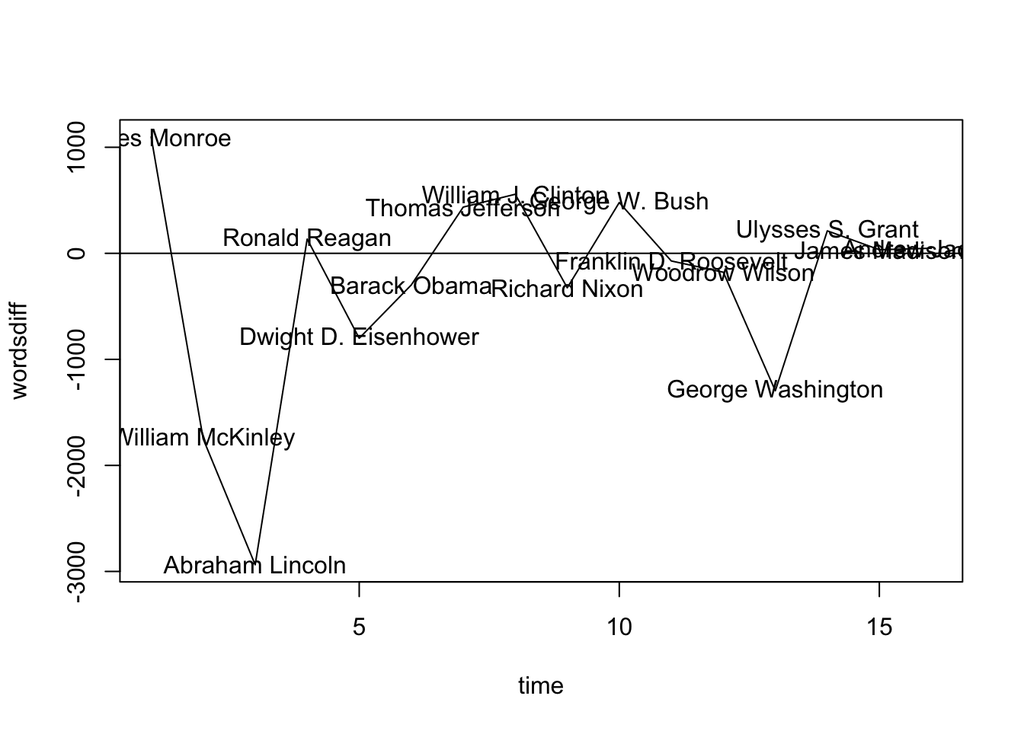

```r
plot(1:nrow(speechdiff),speechdiff$V2,type = "l",xlab = "time", ylab = "wordsdiff")
for (i in 1:nrow(speechdiff)){
  text(x = i,y = speechdiff$V2[i],label = speechdiff$data[i])
}
abline(h = 0)
```

We can see William Henry Harrison writes the longest inauguration speech in US history; part of reason should be the long sentences he used. Most of the presidents have similar length in term 1 speech and term 2 speech if they achieved a reappointment. However, James Monroe has much more to say in his 2nd term speech; Ablaham Lincoln, William McKinley and George Washington do not have much to talk about, in cantrast.

#Step 6 - Create corpus for Republican, text mining, and text processing

```r
repub_corpus.list=Republican_sentence.list[2:(nrow(Republican_sentence.list)-1), ]
sentence.pre=Republican_sentence.list$sentences[1:(nrow(Republican_sentence.list)-2)]
sentence.post=Republican_sentence.list$sentences[3:(nrow(Republican_sentence.list)-1)]
repub_corpus.list$snipets=paste(sentence.pre, repub_corpus.list$sentences, sentence.post, sep=" ")
rm.rows=(1:nrow(repub_corpus.list))[repub_corpus.list$sent.id==1]
rm.rows=c(rm.rows, rm.rows-1)
repub_corpus.list=repub_corpus.list[-rm.rows, ]

repub_docs <- Corpus(VectorSource(repub_corpus.list$snipets))
writeLines(as.character(repub_docs[[sample(1:nrow(repub_corpus.list), 1)]]))
```

```
## To serve it will be hard. And to attain it, we must be aware of its full meaning--and ready to pay its full price. We know clearly what we seek, and why.
```

```r
#remove potentially problematic symbols
repub_docs <-tm_map(repub_docs,content_transformer(tolower))
#remove punctuation
repub_docs <- tm_map(repub_docs, removePunctuation)
#Strip digits
repub_docs <- tm_map(repub_docs, removeNumbers)
#remove stopwords
repub_docs <- tm_map(repub_docs, removeWords, stopwords("english"))
#remove whitespace
repub_docs <- tm_map(repub_docs, stripWhitespace)
#Stem document
repub_docs <- tm_map(repub_docs,stemDocument)
writeLines(as.character(repub_docs[[sample(1:nrow(repub_corpus.list), 1)]]))
```

```
## unit state progress marvel rapid everi field enterpris endeavor becom foremost near great line inland trade commerc industri yet true american merchant marin steadili declin now lower percentag tonnag number vessel employ prior civil war commend progress made late year upbuild american navi must …
```

#Step 7 - topic modelling for Republican corpus We gengerate document-term matrices first

```r
dtm <- DocumentTermMatrix(repub_docs)
#convert rownames to filenames#convert rownames to filenames
rownames(dtm) <- paste(repub_corpus.list$type, repub_corpus.list$File,
                       repub_corpus.list$Term, repub_corpus.list$sent.id, sep="_")

rowTotals <- apply(dtm , 1, sum) #Find the sum of words in each Document

dtm  <- dtm[rowTotals> 0, ]
repub_corpus.list=repub_corpus.list[rowTotals>0, ]
```

Run LDA

```r
#Set parameters for Gibbs sampling
burnin <- 4000
iter <- 2000
thin <- 500
seed <-list(2003,5,63,100001,765)
nstart <- 5
best <- TRUE
#Number of topics
k <- 5
#Run LDA using Gibbs sampling
ldaOut <-LDA(dtm, k, method="Gibbs", control=list(nstart = nstart,
                                                 seed = seed, best = best,
                                                 burnin = burnin, iter = iter,
                                                 thin=thin))
#docs to topics
ldaOut.topics <- as.matrix(topics(ldaOut))
table(c(1:k, ldaOut.topics))
```

```
##
##   1   2   3   4   5
## 636 469 627 419 501
```

```r
write.csv(ldaOut.topics,file=paste("/Users/xuansijian/LDAGibbs","REP",k,"DocsToTopics.csv"))

#top 6 terms in each topic
ldaOut.terms <- as.matrix(terms(ldaOut,6))
write.csv(ldaOut.terms,file=paste("/Users/xuansijian/LDAGibbs","REP",k,"TopicsToTerms.csv"))

#probabilities associated with each topic assignment
topicProbabilities <- as.data.frame(ldaOut@gamma)
write.csv(topicProbabilities,file=paste("/Users/xuansijian/LDAGibbs","REP",k,"TopicProbabilities.csv"))


terms.beta=ldaOut@beta
terms.beta=scale(terms.beta)
topics.terms=NULL
for(i in 1:k){
  topics.terms=rbind(topics.terms, ldaOut@terms[order(terms.beta[i,], decreasing = TRUE)[1:7]])
}
topics.terms
```

```
##      [,1]     [,2]       [,3]      [,4]      [,5]     [,6]
## [1,] "peac"   "freedom"  "free"    "war"     "seek"   "human"
## [2,] "public" "congress" "import"  "product" "proper" "determin"
## [3,] "time"   "let"      "histori" "man"     "god"    "presid"
## [4,] "will"   "can"      "must"    "good"    "believ" "mani"
## [5,] "law"    "state"    "unit"    "union"   "order"  "support"
##      [,7]
## [1,] "common"
## [2,] "necessari"
## [3,] "hand"
## [4,] "effort"
## [5,] "author"
```

```r
ldaOut.terms
```

```
##      Topic 1   Topic 2    Topic 3    Topic 4 Topic 5
## [1,] "nation"  "govern"   "time"     "will"  "law"
## [2,] "world"   "upon"     "new"      "can"   "state"
## [3,] "peac"    "countri"  "america"  "must"  "govern"
## [4,] "freedom" "public"   "american" "peopl" "shall"
## [5,] "free"    "congress" "work"     "make"  "right"
## [6,] "war"     "secur"    "year"     "one"   "peopl"
```

We can see that Republican party has its own advocation on holding traditional and conservative opinions. I regard Topic 1 as about “national security”. Topic 2 seems like to be about “government.” Topic 3 is about “work”. There’s not much thing useful in Topic 4 since there are 3 modal verbs, I can see “people” or “humanity” from Topic 4. Topic 5 looks like about “law”. Indeed, the topics are really like what traditionalists and paleoconservatives want. #Step 5 - create corpus for Democratic, text mining, and text processing

```r
demo_corpus.list=Democracy_sentence.list[2:(nrow(Democracy_sentence.list)-1), ]
sentence.pre=Democracy_sentence.list$sentences[1:(nrow(Democracy_sentence.list)-2)]
sentence.post=Democracy_sentence.list$sentences[3:(nrow(Democracy_sentence.list)-1)]
demo_corpus.list$snipets=paste(sentence.pre, demo_corpus.list$sentences, sentence.post, sep=" ")
rm.rows=(1:nrow(demo_corpus.list))[demo_corpus.list$sent.id==1]
rm.rows=c(rm.rows, rm.rows-1)
demo_corpus.list=demo_corpus.list[-rm.rows, ]

demo_docs <- Corpus(VectorSource(demo_corpus.list$snipets))
#remove potentially problematic symbols
demo_docs <-tm_map(demo_docs,content_transformer(tolower))
#remove punctuation
demo_docs <- tm_map(demo_docs, removePunctuation)
#Strip digits
repub_docs <- tm_map(demo_docs, removeNumbers)
#remove stopwords
demo_docs <- tm_map(demo_docs, removeWords, stopwords("english"))
#remove whitespace
demo_docs <- tm_map(demo_docs, stripWhitespace)
#Stem document
demo_docs <- tm_map(demo_docs,stemDocument)
writeLines(as.character(demo_docs[[sample(1:nrow(demo_corpus.list), 1)]]))
```

```
## act quick bold decis later year live years<e2><80><94>fruit year peopl democraci brought us greater secur hope better understand life ideal measur materi thing
```

#Step 8 - topic modelling for Democratic corpus

```r
dtm <- DocumentTermMatrix(demo_docs)
#convert rownames to filenames#convert rownames to filenames
rownames(dtm) <- paste(demo_corpus.list$type, demo_corpus.list$File,
                       demo_corpus.list$Term, demo_corpus.list$sent.id, sep="_")

rowTotals <- apply(dtm , 1, sum) #Find the sum of words in each Document

dtm  <- dtm[rowTotals> 0, ]
demo_corpus.list=demo_corpus.list[rowTotals>0, ]
```

Run LDA

```r
#Set parameters for Gibbs sampling
burnin <- 4000
iter <- 2000
thin <- 500
seed <-list(2003,5,63,100001,765)
nstart <- 5
best <- TRUE
#Number of topics
k <- 5
#Run LDA using Gibbs sampling
ldaOut <-LDA(dtm, k, method="Gibbs", control=list(nstart = nstart,
                                                 seed = seed, best = best,
                                                 burnin = burnin, iter = iter,
                                                 thin=thin))
#docs to topics
ldaOut.topics <- as.matrix(topics(ldaOut))
table(c(1:k, ldaOut.topics))
```

```
##
##   1   2   3   4   5
## 460 332 508 304 262
```

```r
write.csv(ldaOut.topics,file=paste("/Users/xuansijian/LDAGibbs","DEM",k,"DocsToTopics.csv"))

#top 6 terms in each topic
ldaOut.terms <- as.matrix(terms(ldaOut,6))
write.csv(ldaOut.terms,file=paste("/Users/xuansijian/LDAGibbs","DEM",k,"TopicsToTerms.csv"))

#probabilities associated with each topic assignment
topicProbabilities <- as.data.frame(ldaOut@gamma)
write.csv(topicProbabilities,file=paste("/Users/xuansijian/LDAGibbs","DEM",k,"TopicProbabilities.csv"))


terms.beta=ldaOut@beta
terms.beta=scale(terms.beta)
topics.terms=NULL
for(i in 1:k){
  topics.terms=rbind(topics.terms, ldaOut@terms[order(terms.beta[i,], decreasing = TRUE)[1:7]])
}
topics.terms
```

```
##      [,1]       [,2]        [,3]      [,4]      [,5]       [,6]
## [1,] "men"      "freedom"   "purpos"  "man"     "histori"  "use"
## [2,] "peopl"    "everi"     "good"    "faith"   "polit"    "need"
## [3,] "american" "work"      "togeth"  "generat" "centuri"  "see"
## [4,] "war"      "prosper"   "present" "practic" "progress" "danger"
## [5,] "state"    "constitut" "preserv" "foreign" "within"   "action"
##      [,7]
## [1,] "help"
## [2,] "confid"
## [3,] "children"
## [4,] "far"
## [5,] "feder"
```

```r
ldaOut.terms
```

```
##      Topic 1  Topic 2  Topic 3    Topic 4    Topic 5
## [1,] "nation" "will"   "must"     "countri"  "govern"
## [2,] "can"    "peopl"  "new"      "one"      "power"
## [3,] "great"  "everi"  "world"    "union"    "state"
## [4,] "life"   "spirit" "american" "interest" "shall"
## [5,] "men"    "public" "time"     "peac"     "upon"
## [6,] "human"  "hope"   "america"  "protect"  "right"
```